# [COURS3] Interaction spatiale et territoriale (1998)

### 4.4.2 Un exemple d’application du problème de la partition inconnue

Supposons que nous voulions vérifier si la division en deux républiques correspond à la partition qui donne le meilleur ajustement des flux entre les 10 régions tchécoslovaques en 1961-65 à l’aide d’un modèle d’interaction spatiale et territoriale. La seule façon de s’en assurer est de tester l’ensemble des partitions et de mesurer leur qualité d’ajustement. Toutefois, même avec 10 régions, le nombre de partition possible est très élevé. On peut donc poser un certain nombre de conditions restrictives afin de n’examiner que les partitions qui sont comparables à la division en deux républiques. On limitera donc la recherche aux partitions qui vérifient les conditions suivantes :

- partition en deux entités spatiales (fixation du nombre de classes)
- entités spatiales composées de régions connexes (contrainte de continuité territoriale)

Seules 48 partitions vérifient ces deux conditions et l’on peut alors procéder à un examen exhaustif de leurs paramètres ($\alpha, \gamma$) et de leur qualité d’ajustement ($r^2$). L’examen du paramètre de barrière montre que 25 partitions correspondent à des effets de barrière ($\gamma > 1$) et 23 à des effets d’anti-barrière ($\gamma< 1$). Le classement des partitions en fonction de la qualité d’ajustement des modèles d’interaction spatiale et territoriale montre que la division en deux républiques (partition B1) n’arrive qu’en deuxième position avec une qualité d’ajustement de 93.1% . La partition optimale (A1) a une qualité d’ajustement légèrement supérieure (93 .2%) et correspond à un modèle d’anti-barrière dont les paramètres sont $\alpha = -1.82$ et $\gamma =0.57$. Elle oppose quatre régions de Bohême (nord, centre, ouest et sud) au reste du pays. Comme il s’agit d’un effet d’anti-barrière, les flux intra-maille sont proportionnellement plus faibles que les flux inter-mailles, toutes choses égales quant à la distance. En effet, cette partition regroupe des régions qui échangent moins de migrant que ce que laisserait présager leur proximité (e.g. Bohême-nord et Bohême-centre ou Moravie-sud et Slovaquie-ouest) tandis qu’elle sépare des régions qui échangent plus que ce que laisserait prévoir leur proximité (e.g. Slovaquie-ouest et Bohême-nord ou Bohême-centre et Bohême-sud). Il n’y a donc rien de paradoxal au fait que le meilleur modèle descriptif soit un modèle d’anti-barrière regroupant les régions qui sont les moins intégrées.

L’examen de l’histogramme des qualités d’ajustement montre d’ailleurs que 6 des 7 meilleures partitions correspondent à des modèles de type anti-barrière et se détachent nettement des partitions suivantes dont les qualités d’ajustement sont équivalentes et beaucoup plus faibles. Les meilleures partitions avec effet d’anti-barrière présentent d’ailleurs de fortes ressemblances entre elles (e.g. A1 et A2 ou A3 et A5) puisqu’elles visent toutes à regrouper les régions proches qui échangent moins de migrant que ce que laisserait prévoir leur proximité. Ceci explique sans doute pourquoi les meilleures partitions avec effet d’anti-barrière ont des qualités d’ajustement assez voisine, aucune ne se détachant nettement des autres.

Il n’en va pas de même pour les partitions avec effet de barrière où la division en deux républiques (B1) a une qualité d’ajustement nettement meilleure que les suivantes (B2 à B6). En effet, dès que l’on permute une ou plusieurs régions pour les faire passer dans l’autre république, on observe une chute très importante de la valeur du coefficient de barrière et de la qualité d’ajustement. On peut donc affirmer que dès la période 1961-65, la division en deux républiques est incontestablement celle qui permet de constituer les entités territoriales les plus intégrées sur le plan migratoire, tout au moins par rapport aux contraintes qui ont été fixées en ce qui concerne le nombre de classes et leur contrainte de contiguïté .

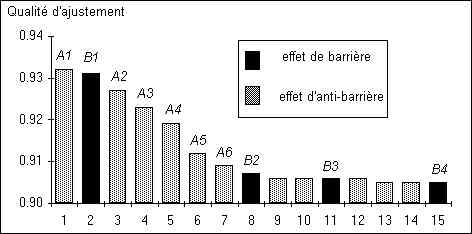

Qualité d’ajustement des modèles migratoires en fonction du choix de la partition (Tchécoslovaquie- 1961-65 ; 2 classes avec contrainte de contiguïté)

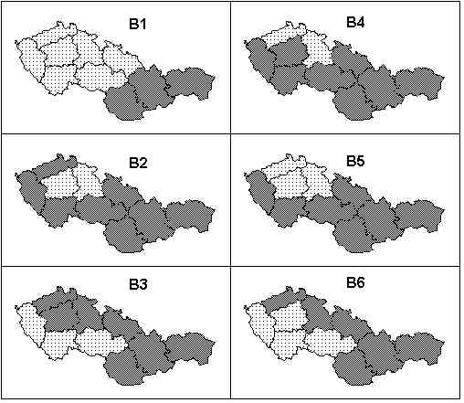

Définition des 6 meilleures partitions associées à un effet de barrière (Tchécoslovaquie 1961-65 ; 2 classes ; contrainte de contiguïté)

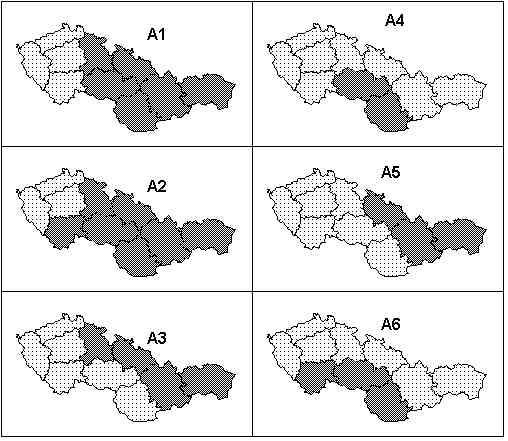

Détermination des 6 meilleures partitions associées à un effet d’anti-barrière (Tchécoslovaquie 1961-65 ; 2 classes ; contrainte de contiguïté)

Si l’on reprend le même protocole d’analyse pour la période 1986-90, on observe un bouleversement très important de la hiérarchie des partitions .En effet, la partition en deux républiques (B1) apparaît désormais nettement comme la partition optimale et son pouvoir explicatif est très nettement supérieure à l’ensemble des autres, qu’elles correspondent à des barrières ou des anti-barrières. L’augmentation de l’effet de barrière entre les deux républiques s’est donc accompagné d’une induration de la structure territoriale des échanges où, si l’on préfère d’une homogénéisation et d’une généralisation de l’effet de barrière qui exclue tout autre structure descriptive alternative. Par rapport au système descriptif adopté, la partition en deux républiques est incontestablement celle qui permet le mieux de rendre compte de l’organisation des échanges entre les dix régions de Tchécoslovaquie.

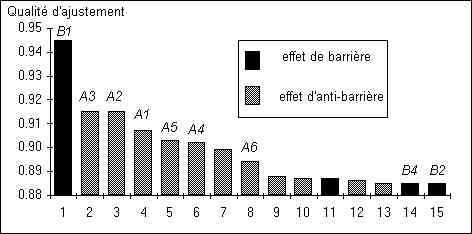

Qualité d’ajustement des modèles migratoires en fonction du choix de la partition (Tchécoslovaquie 1986-90 ; 2 classes ; contrainte de contiguïté)

Il convient également d’ajouter que la méthode retenue dans l’exemple précédent (examen exhaustif de l’ensemble des partitions) n’est applicable actuellement qu’à des matrices de migrations de tailles très réduites (25 x25). Mais le programme de recherche que nous avons développé avec le LMC-IMAG devrait bientôt permettre des applications sur des matrices de taille beaucoup plus importante.

### 4.4.3 Le problème de la partition inconnue et l ’étude de la dynamique des fragmentations territoriales

Si le problème de la partition inconnue possède une incontestable ” beauté mathématique ” en raison de sa complexité et du fait qu’il existe ” au moins une solution “, il est également du plus haut intérêt sur le plan empirique et sur le plan théorique pour l’analyse géographique des fragmentations socio-territoriales.

D’un point de vue empirique, tout d’abord, la recherche d’une partition optimale permet d’améliorer les modèles de prévisions puisqu’elle permet de déterminer la combinaison de paramètre qui donne l’ajustement le plus efficace compte tenu de l’information disponible. Après avoir déterminé la partition optimale sur un ensemble de périodes, on peut examiner l’évolution temporelle des paramètres correspondant d’interaction spatiale ($\alpha$) et d’interaction territoriale ($\gamma$) à différentes dates et essayer d’extrapoler les tendances de leur évolution. On a ainsi de fortes chances d’obtenir une prévision plus juste que celle qui aurait été réalisée à l’aide d’une simple analyse des variations de la mobilité générale et du frein de la distance. On peut également - mais c’est beaucoup plus compliqué - examiner l’évolution de la partition optimale à différentes dates et essayer d’analyser si son évolution obéit à certaines règles. En effet, un effet de barrière ne correspond pas nécessairement à une limite stable mais peut se déplacer selon un front de progression, certaines unités territoriales voyant leur appartenance se modifier ou s’inverser au cours du temps. Ainsi, dans le cas tchécoslovaque nous avons pu observer qu’il existait deux effets de barrières en 1961-65 (l’un entre la Bohême et la Moravie, l’autre entre la Moravie et la Slovaquie) qui se sont progressivement fondus en un seul à partir de 1970 (entre la république Tchèque et la Slovaquie). Nous avons également pu montrer dans le cas de la Belgique que les sous-provinces de Brabant-Nord et de Bruxelles qui faisaient office de zone-tampon au début des années 1960 se sont progressivement rattachées, l’une au domaine migratoire flamand et l’autre au domaine migratoire wallon.

Ceci nous amène à l’intérêt non plus empirique mais théorique du problème de la partition inconnue qui est de ne pas préjuger a priori de la forme et de la localisation des effets de barrière existant à l’intérieur d’un certain espace. En effet lorsque l’on adopte une démarche déductive (fixation d’une partition a priori), la modélisation tend souvent à conforter l’hypothèse initiale en montrant que la partition choisie correspond bien à un effet de barrière et fournit une bonne description du comportement des migrants. Mais ce résultat, s’il démontre que l’hypothèse retenue est acceptable, ne prouve pas que c’est la meilleure hypothèse possible. Il est donc nécessaire de valider l’hypothèse initiale (e.g. ” les migrations en Tchécoslovaquie sont influencées par l’appartenance aux deux républiques tchèque et slovaque “) en comparant son pouvoir explicatif à celui d’hypothèses alternatives (e.g. ” les migrations en Tchécoslovaquie sont influencées par l’appartenance aux trois régions historiques de Bohême, Moravie et Slovaquie “). L’intérêt central de la méthode de la partition inconnue est d’adopter une démarche inductive et de ne privilégier a priori aucune hypothèse quant à la localisation précise des barrières. Tout au plus doit-on spécifier quelles sont les contraintes retenues pour trouver la solution optimale (e.g. ” quelle partition en deux classes territoriales contiguës influence le plus le comportement migratoire des populations en Tchécoslovaquie “).

Du coup, le problème de la partition inconnue suggère une autre approche de la mesure des barrières qui consiste non pas à déterminer un coefficient de réduction des échanges mais à comparer le pouvoir explicatif de la meilleure partition et des suivantes. En effet, on peut considérer qu’une structure territoriale est d’autant plus pertinente qu’elle se démarque nettement des autres structures territoriales susceptibles de rendre compte du même phénomène.

## 4.5 Estimation d’effets de barrière complexes (interaction entre distance et appartenance territoriale)

L’amélioration théorique et méthodologique apportée par la famille des modèles d’interaction spatiale et territoriale multiplicatifs développés précédemment ne doit pas dissimuler le fait qu’il ne s’agit toujours que d’une solution particulière. En effet, le choix d’une forme multiplicative dans la modélisation des relations entre distance et appartenance est fondé sur un postulat d’homogénéité de l’effet de barrière. Plus précisément, la forme multiplicative présuppose que l’importance de l’effet de barrière est indépendante de la distance de relation. Par exemple, si l’on a trouvé que l’effet de barrière à une valeur moyenne de 2, on suppose que tous les flux franchissant une limite territoriale subissent en moyenne une réduction de moitié, qu’il s’agisse de flux à courte, moyenne ou longue distance. Or, rien n’indique que ce postulat soit vérifié. On peut au contraire imaginer que les personnes situés à très courte distance d’une frontière subissent moins l’effet de barrière car ils sont mieux informés de la situation dans la maille territoriale voisine, connaissent mieux sa langue, etc. Ainsi, le fait que beaucoup d’Alsaciens aillent travailler en Allemagne s’explique non seulement par leur proximité spatiale mais aussi par leur proximité culturelle et linguistique qui permet de lever un certain nombre d’obstacles. Toutefois, on pourrait imaginer des situations différentes où l’effet de barrière diminue avec la distance. Ainsi, dans le cas où une limite territoriale marque la trace d’un conflit entre les peuples situés de part et d’autres, on peut supposer que les facteurs psychologiques d’hostilité ou de méfiance réciproque sont davantage marqués à courte distance qu’à longue distance. Bref, on peut imaginer toutes sortes de théories qui conduisent à supposer que l’effet de barrière varie en fonction de la distance, quel que soit le sens de cette variation.

Si tel est le cas, il convient de réviser nos hypothèses sur la forme multiplicative du modèle d’interaction géographique et de rechercher des formes plus complexes de relation entre la distance et l’appartenance. De plus, si l’effet de barrière varie en fonction de la distance, les mesures qui pourront en être faite vont subir fortement l’influence du niveau d’observation retenu (taille des unités spatiales) puisque la taille du maillage d’observation conduit à majorer ou au contraire à minorer l’importance des relations à courte distance par rapport aux relations à longue distance. De la même manière, les critères d’ajustement peuvent influer sur le calcul de l’effet de barrière si celui-ci varie en fonction de la distance. En effet, les différentes méthodes d’ajustement accordent un poids plus ou moins important aux flux en fonction de leur volume. Or, le volume est généralement corrélé avec la distance, les flux les plus important en volume se nouant en général entre des régions proches. Du coup, un changement de pondération correspond à un changement du poids relatif des relations à courte, moyenne ou longue distance dans l’évaluation des effets de distance et d’appartenance.

D’une manière générale, si l’on observe une instabilité de l’effet de barrière en fonction du choix de la méthode d’ajustement ou du choix du niveau d’observation, il y a de fortes chances que cette instabilité soit liée à une variation de l’effet de barrière en fonction de la distance, c’est-à-dire à une hypothèse incorrecte sur le lien entre distance et appartenance.

### 4.5.1 Définition d’un modèle général

Que l’on utilise un modèle gravitaire ou un modèle à double contrainte le calcul d’un coefficient de barrière unique dérive de l’hypothèse d’une relation simple entre l’effet de la proximité spatiale et l’effet de la proximité territoriale. Dans un modèle multiplicatif, les deux effets sont combinés sous la forme d’un produit, ce qui revient à dire que la fonction d’interaction géographique G (effet combiné de la proximité spatiale et de la proximité territoriale) est décomposable en deux termes indépendants exprimant l’interaction spatiale S et l’interaction territoriale T.

$G(D_{ij}, A_{ij}) = S(D_{ij}) . T(A_{ij})$

Les différentes fonctions de la distance expriment le comportement spatial des migrants appartenant à chacune des classes d’appartenance territoriales. Il y a donc a priori autant de fonctions d’interaction spatiales qu’il y a de types de proximité territoriale.

### 4.5.3 Application du modèle général au cas des fonctions d’interaction spatiale de type Paréto

Nous partirons d de l’hypothèse qu’il existe deux lois d’interaction spatiale $f_0(d_{ij})$ et $f_1(d_{ij})$ décrivant respectivement la décroissance des flux intra-maille et des flux inter-mailles en fonction de la distance. On se place dans le cas d’un modèle gravitaire sans contraintes, et on suppose que les deux fonctions d’interaction spatiales obéissant à une loi de Paréto :

$F^0_{ij} = k_0. E_i . R_j . d_{ij}^{-\alpha_0}$ (relations intra-mailles)

$F^1_{ij} = k_1. E_i . R_j . d_{ij}^{-\alpha_1}$ (relations inter-mailles)

On en déduit une équation générale décivant le comportement de l’ensemble des relationsintra-mailles ou inter-mailles :

$F_{ij} = k_0. E_i. R_j . d_{ij}^{\alpha_0}. [(k_1/k_0). d_{ij}^{(\alpha_1-\alpha_0)}]^{A_{ij}}$

La fonction décrivant la variation de l’effet de barrière en fonction de la distance est donc :

$\gamma(d_{ij}) = (k_1/k_0). d_{ij}^{(\alpha_1-\alpha_0)}$

Cette fonction n’est constante que si ($\alpha_1 = \alpha_0$), ce qui montre clairement que l’hypothèse d’un effet de barrière homogène (indépendant de la distance parcourue) n’est valide que si la vitesse de décroissance des interactions avec la distance est la même pour les flux intra-maille et pour les flux inter-mailles. Si la décroissance des interactions avec la distance est plus rapide pour les flux inter-maille que pour les flux intra-maille ($\alpha_1 > \alpha_0$) l’effet de barrière aura tendance à s’accroître avec la distance. Inversement, si la décroissance des interactions avec la distance est plus rapide pour les flux intra-mailles que pour les flux inter-mailles ($\alpha_1 < \alpha_0$), l’effet de barrière aura tendance à diminuer avec la distance.

Si l’on définit maintenant X comme le logarithme de la distance, on peut montrer que le modèle de Paréto correspond à une fonction d’interaction spatiale définie par l’exponentiel d’un polynome P1(X) de degré 1.

L’effet de barrière peut donc être non seulement variable avec la distance, mais aussi présenter des minima et des maxima si les degrés du polynôme supérieur ou égaux à 2 ne sont pas nuls. Il convient toutefois de préciser que les valeurs de l’effet de barrière ne sont significatives que sur l’intervalle de distance commun aux flux intra-mailles et aux flux inter-mailles. L’intervalle d’étude de g (d) risque d’être encore plus réduit si l’on tient compte du fait que son incertitude de mesure dépend à la fois de l’incertitude d’estimation de la fonction d’interaction intra-maille et de celle de la fonction d’interaction inter-mailles. Au total, il peut donc arriver que l’estimation des variations de l’effet de barrière en fonction de la distance soit impossible ou peu fiable car on ne dispose pas d’échantillons suffisant de flux intra-mailles et de flux inter-mailles pour les mêmes gammes de distance.

### 4.5.4 Typologie des variations de l’effet de barrière en fonction de la distance

L’analyse des paramètres du modèle polynomial suggère que, d’un point de vue théorique, on peut donc définir cinq grandes familles de situations en ce qui concerne la variation de l’effet de barrière en fonction de la distance. Si on note k le degré minimum du polynôme rendant compte de la variation de l’effet de barrière en fonction de la distance et $g_0, g_1,...g_k$ les paramètres de ce polynome on peut distinguer les cas suivants :

Il va de soi qu’une typologie équivalente pourrait être établie pour les anti-barrières en remplaçant la condition g0>1 par la condition g0<1 dans les expressions précédentes.

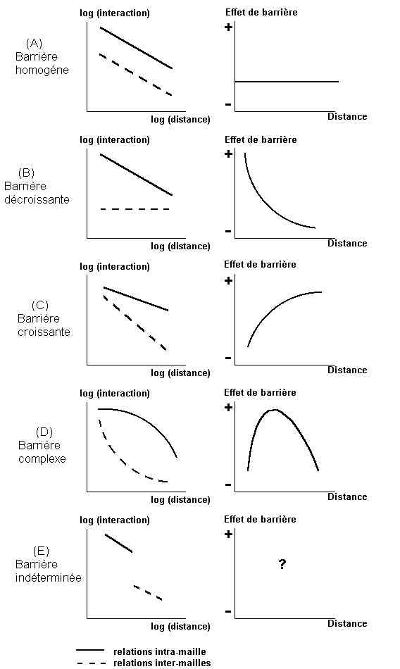

Typologie des variations de l’effet de barrière en fonction de la distance

### 4.5.5 Exemple d’application empirique : les migrations entre les provinces Belges en 1989

Partant d’un modèle gravitaire simple et sans contrainte, on constate que les flux migratoires entre les provinces belges varient en fonction de l’appartenance linguistique (Flandres / Wallonie+Bruxelles). Mais la forme du graphique d’interaction suggère que l’effet de barrière n’est pas indépendant de la distance parcourue par les migrants.

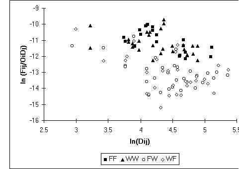

Etape 1

[output not shown]

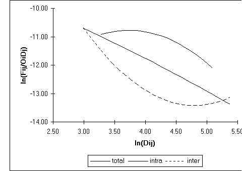

Etape 2

On déduit de l’équation des polynômes décrivant les comportements intra- et inter-linguistique la forme générale de la variation de l’effet de barrière en fonction de la distance.

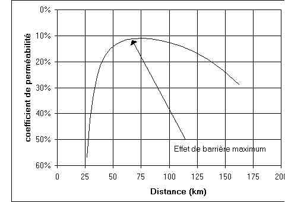

Etape 3

Le graphique obtenu permet de montrer que l’effet de barrière varie très fortement en fonction de la distance. Faible pour les migrations à courte distance (division par 2 à 30 km) il culmine à moyenne distance (division par 9 à 75 km) et diminue ensuite régulièrement pour les distances les plus grandes (division par 3 à 160 km).

Plusieurs facteurs expliquent ces variations, notamment le rôle de l’agglomération bruxelloise située à cheval sur la limite linguistique (et qui favorise les transgressions de la limite linguistique à courte distance) ou celui des aires de villégiature situées aux extrémités opposées du pays (côte de la Mer du Nord en Flandres et région des Ardennes en Wallonie) et qui attirent des migrants de l’ensemble du pays à longue distance.

Mais la forme en cloche de l’effet de barrière observée en Belgique ne constitue pas un cas isolé et on l’observe également pour les migrations inter-républiques en Tchécoslovaquie ou pour les échanges internationaux de marchandise entre les régions de France et de Belgique.

Il semble exister certaines explications théoriques de portée générale permettant de rendre compte de la non-linéarité des effets de barrière et de l’apparition d’un maximum de l’effet de barrière à moyenne distance. Toutefois, leur discussion nécessiterait une discussion détaillée qui dépasse le cadre du présent exposé.

On se bornera donc à rappeler la fréquence de ce type de situation et de mettre en garde l’utilisateur des modèles d’interaction spatiale contre les formulations de l’effet de barrière multiplicative simples, ne prenant pas en compte les variations possibles de l’effet de barrière en fonction de la distance. Un simple graphique, du type de celui que nous avons utilisé pour caractériser les interactions en Belgique, suffit souvent à repérer le type de la relation barrière-distance et permet de suggérer la forme de modélisation la plus appropriée.